# Game Theory 1

September 7, 2018

## Pregame

- Tomorrow is WSU’s first football game! Warning that there will be almost no parking on campus.

## Feedback

### Good:

- I liked the examples, they were relatable and enjoyable
- I like specific key terms
- it was *kind of* interesting

### Needs improvement:

- The graphs are confusing
- Understanding of MC, ATC, AVC, etc… is shaky

### Ambiguous:

- If you wore a fur coat I could maybe see some resemblance to Jon Snow. Also if you let your hair down and let it fluff out.

## Oh God what have I done?

[interactive chart not shown]

[via GIPHY](https://giphy.com/gifs/l2RnCHvTVK5g4X31e)

## Game Theory

- K&W treats game theory as an afterthought for oligopoly markets, but game theory is extensive and has become one of the most crucial aspects fo economics analysis.
- We will work primarily from [The Economy Chapter 4](https://core-econ.org/the-economy/book/text/04.html).

## Game Theory - An introduction

[video not shown]

## What is Game Theory?

*Game Theory is the study of behavior when there is the possibility for strategic interaction.*

- **Strategic interaction** occurs when people are engaged in a social interaction and are aware of the ways that their actions affect others, and vice versa. In other words, the people are *interdependent*.

## Game Theory - oligopoly example

- If there are only a few coffee shops in town, a price change by one affects the prices set by the others. In contrast, if there are many, a price change by one does not really affect the average price of the market, so other coffee shops will not behave any differently.

## Game Theory - relationship example

- Couples engage in strategic interation. You know that your choice affects your partner and their choice affects you, and you know that each other knows that.

Suppose you would prefer to go see a movie tomorrow, but your partner would rather go see the football game. Fortunately you like each other so you prefer spending time together over spending time apart.

## Game Theory - Employer/Employee example

- the relationship between an employer and an employee is interdependent, since the employer often cannot easily observe the employee’s level of effort and the employee knows that.

Suppose next year you work as a TA for this class. You are supposed to show up for tutoring, but your boss doesn’t monitor whether you are there the whole time. The payoff the department gets (in terms of students helped) depends on your actions, but you have the option to shirk and if no one shows up, you won’t lose your job.

## Some definitions for games

- **Game** - *A model of strategic interactions.*
- **Player** - *A player in a game.*
- **Strategy** - *Feasible action(s) that an agent can take.*
- **Payoff** - *The benefit or cost a player recieves from the outcome of a game.*
- **Dominant Strategy** - *A strategy that yields a higher payoff than any other strategy, regardless of the other player’s actions.*
- **Complete information** - *All players know the payoffs of all players and the available strategies of all players.*

## Sometimes it can get a little dizzying…

[video not shown]

## An example with farming

- Two farmers (Anil and Bala) decide whether to grow cassava or rice.
- Anil’s land is better for cassava and Bala’s land is better for rice.
- They choose independently, without interacting.

## The game

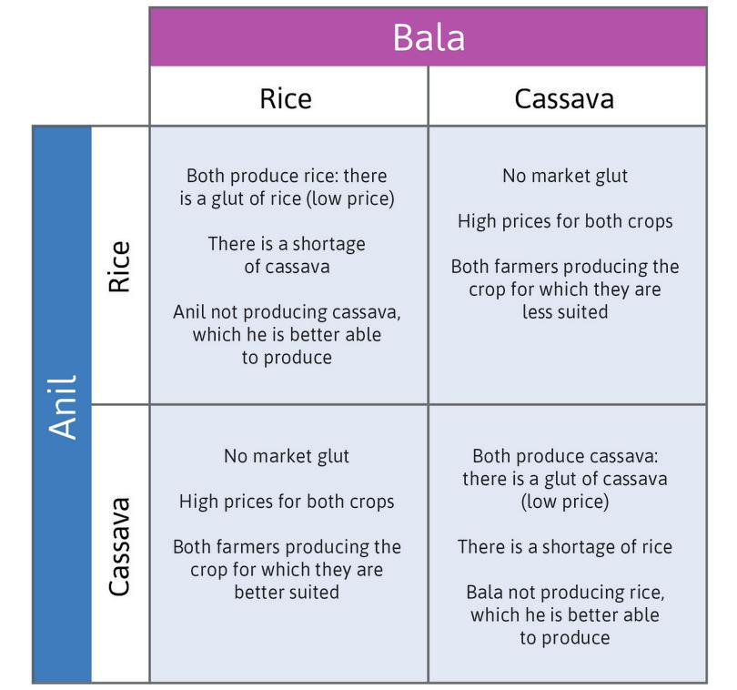

## The game payoffs

[Walkthrough](https://core-econ.org/the-economy/book/text/04.html#figure-4-2b-a)

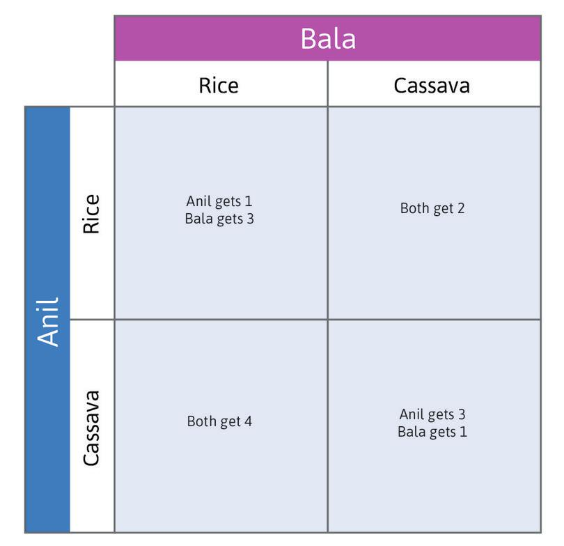

## Results from the game

- Anil chooses cassava, Bala chooses rice, yielding a payoff of (4,4).
- This is a **dominant strategy equilibrium**, since neither player has an incentive to switch.
- The previous game matches the outcomes of a market model, in which each player chooses independently and optimizes, resulting in the most effecient production.
- But what if Anil’s choice imposes costs or benefits on Bala, and Bala’s choice imposes costs or benefits on Anil?

## A game with social costs

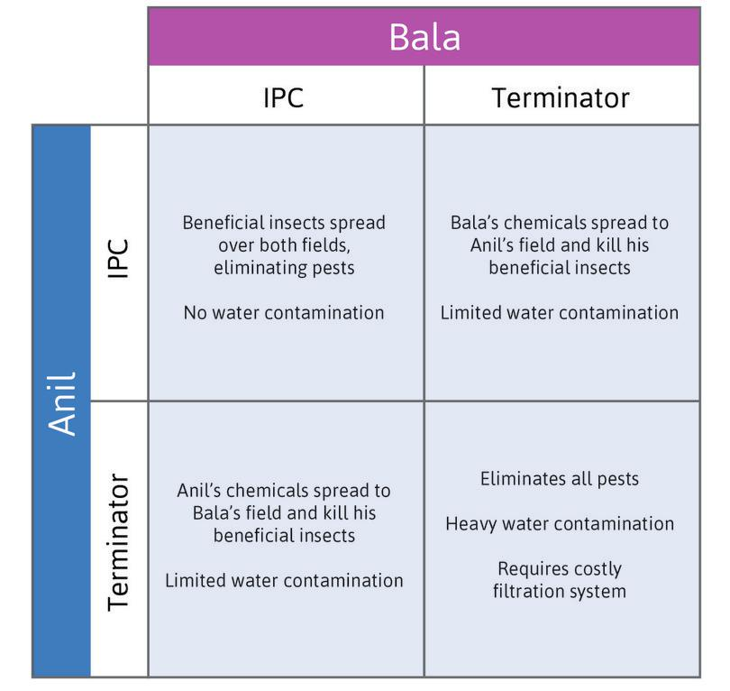

## A game with social costs - payoffs

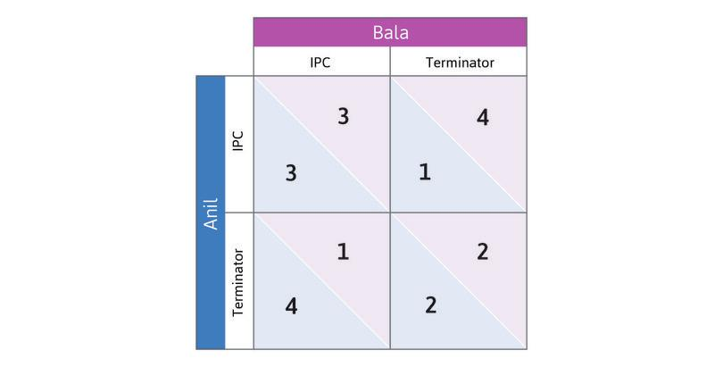

## The prisoner’s dilemma

[video not shown]

## Wrapping Up

- Complete the [knowledge check](https://goo.gl/forms/YKmR70ALy8ZF3Kmx2) for today’s participation point.
- Please provide [feedback](https://goo.gl/forms/8SiOwdi19kN8cINJ3) on today’s lecture.